# Methods of Empirical Finance

## Seminar (UE)

### Christoph Huber

### University of Innsbruck

#### Master in Banking and Finance

### Winter term 2019/20 (this version: 2019-12-10)

# Time Series Analysis

### Methods of Empirical Finance

<footer></footer>

# Time Series Analysis

### Time Series Processes

> A time series `\(\{y_t\}\)` is an ordered set of (random) variables, where the (time) ordering is important.

> Data obtained from observations collected _sequentially_ over time.

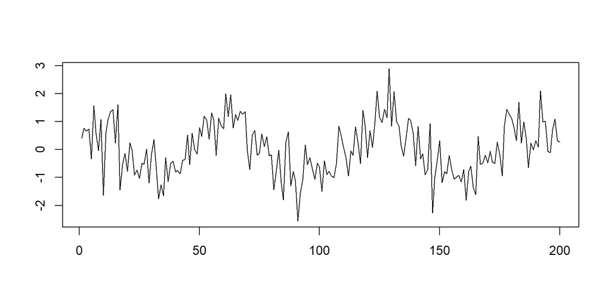

__Notation:__ Observations `\(y_t\)`, at time `\(t = 1, ..., T\)`.

__Goals:__ _Explanation_ (understand or model the stochastic mechanism underlying the series) and _Prediction_ (Forecast future values)

<footer></footer>

# Time Series Analysis

### Univariate and Multivariate Time Series Analysis

- time series analysis accounts for the fact that data points taken over time may
have an _internal structure_ that could be utilized to draw conclusions about the
series’ movements and to make predictions about its future path

- the aim of time series analysis is to find an appropriate statistical model for the
data and to use this model for prediction: in this way, _the variables are allowed
to speak for themselves_, without the "confines" of economic theory

- __univariate time series models__ are a class of specifications to model and predict
variables using only information contained _in their own past values_ (and possibly
current and past values of an error term)

- __structural models__, on the other hand, are
multivariate in nature, and attempt to explain changes in a variable by reference
to the movements in the current or past values of other (explanatory) variables
(e.g., vector auto-regressive models, VAR)

- `\(\rightarrow\)` time series analyses can be applied to get knowledge about the underlying
_data generating process_, to __estimate inherent patterns__ like trends, seasonality, or
cyclical components, and to test economic hypotheses

<footer></footer>

# Time Series Analysis

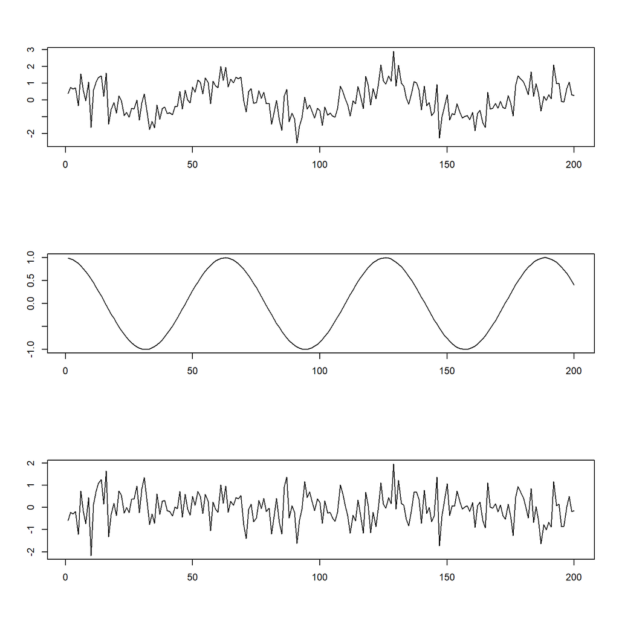

<footer></footer>

# Time Series Analysis

### Time Series Operators

- the `\(i^{th}\)` __difference operator__ is defined by

`\(\Delta_i y_t = y_t - y_{t-i}\)`

Examples:

- first difference operator: `\(\Delta y_t = y_t - y_{t-1}\)`

- second difference operator: `\(\Delta y_t = y_t - y_{t-2}\)`

- Seasonal differencing, e.g.: `\(\Delta y_t = y_t - y_{t-12}\)`

In R: `diff()`

<footer></footer>

# Time Series Analysis

### Time Series Operators

- the __lag operator__ is defined as

`\(Ly_t = y_{t-1}\)`

- more generally: `\(L^{k} y_t = y_{t-k}\)`

- thus, `\(y_t + \alpha_1 y_{t-1} + \alpha_2 y_{t-2} = (1 + \alpha_1 L + \alpha_2 L^2) y_t\)`

In R: `lag()`

<footer></footer>

# Time Series Analysis

### Mean and Variance of Time Series

- time series may have both __stochastic__ and __deterministic__ components, e.g.,
a series with a deterministic trend and a stochastic white noise component:

`\(y_t = \alpha + \beta t + \varepsilon_t \hspace{2em} \text{where } \varepsilon_t \sim i.i.d(0, \sigma^2)\)`

- most time series models of financial markets will have a stochastic component,
and so the __unconditional expectation__ and variance of the `\(t^{th}\)` observation on
the time series can be calculated; for example in the model above

`\(\mu_{y_t} = E[y_t] = E[\alpha + \beta t + \varepsilon_t] = \alpha + \beta t\)`

`\(\lambda_0 = Var[y_t] = E[(y_t - E[y_t])^2] = E[(\alpha + \beta t + \varepsilon_t - \alpha + \beta t)^2] = E[\varepsilon_t^2] = \sigma^2\)`

<footer></footer>

# Time Series Analysis

### Autocovariance and Autocorrelation of Time Series

- the `\(s^{th}\)`__-order autocovariance__ of some time series `\(\{y_t\}\)`,
i.e., the unconditional covariance of `\(y_t\)` and `\(y_{t−s}\)` (that is, the
unconditional covariance _at lag s_ is

`\(\lambda_s = Cov[y_t, y_{t-s}] = E[(y_t - E[y_t])(y_{t-s} - E[y_{t-s}])]\)`

- for instance, for the series above, the `\(s^{th}\)`-order autocovariance is

`\(\lambda_s = Cov[y_t, y_{t-s}] = E[(\alpha + \beta t + \varepsilon_t - \alpha + \beta t)(\alpha + \beta t + \varepsilon_{t-s} - \alpha + \beta t)]\)`

`\(= E[\varepsilon_t \varepsilon_{t-s}] = 0\)`

- the __autocorrelation function__ is then defined by

`\(\rho_s = Corr[y_t, y_{t-s}] = \frac{\lambda_s}{\lambda_0}\)`

<footer></footer>

# Time Series Analysis

### Autocovariance and Autocorrelation of Time Series

- the __partial autocorrelation function__ between `\(y_t\)` and `\(y_{t-s}\)` is is the correlation between `\(y_t\)` minus the part explained by intervening lags and `\(y_{t-s}\)` (where `\(E^*\)` is the minimum mean-squared error prediction of `\(y_t\)` by `\(y_{t-1}, ..., y_{t-s+1}\)`)

`\(\rho_s^* = Corr[y_t - E^*[y_t | y_{t-1}, ..., y_{t-s+1}], y_{t-s}]\)`

- thus, the partial autocorrelation gives the partial correlation of a time series eith its own lagged values, controlling for intervening effects of values at shorter lags

<footer></footer>

# Time Series Analysis

### Returns in Financial Analysis and Modeling

- Starting point is often __prices__, however, most often it is preferable to work with _returns_, i.e., prices have to be converted to returns

### Arithmetic and logarithmic returns

- let `\(p_t\)` denote the price at time `\(t\)`; the simple "arithmetic" return `\(R_t\)` and the _continuously compounded_ logarithmic return `\(r_t\)` are then defined by

`\(R_t = \frac{p_t - p_{t-1}}{p_{t-1}} \hspace{3em} r_t = ln\left(\frac{p_t}{p_{t-1}}\right)\)`

- arithmetic returns are _not symmetric_: e.g. an increase by 50% and a decrease by 50% lead to a total change of -25%

- log returns (continuously compounded returns) are _time-additive_ but not additive across portfolios

<footer></footer>

# Stationarity

<footer></footer>

# Stationarity

### Weak Stationarity

> A time series process `\(\{y_t\}\)` is said to be covariance stationary or
> weakly stationary of the following requirements are satisfied:

> 1. `\(E[y_t] = \mu\)`
> 2. `\(Var[y_t] = \lambda_0^2 < \infty\)`
> 3. `\(Cov[y_t, y_{t-s}] = \lambda_{t, t-s} \forall t, t-s\)`

That is, a time series process is _weakly stationary_ if `\(...\)`

- the mean is constant (independent of `\(t\)`),

- the variance is a finite, positive constant, independent of `\(t\)`, and

- the auto-covariance is a finite function of the lag `\(s\)`, but not of
  the absolute location of either observation on the time scale

<footer></footer>

# Stationarity

### Strong Stationarity

> A time series process `\(\{y_t\}\)` is said to be strictly stationary or
> strongly stationary if  the joint probability distribution of any set of `\(k\)`
> observations in the sequence `\(\{y_t, y_{t+1}, ..., y_{t+k}\}\)` is the same
> regardless of the origin `\(t\)` in the time scale.

That is, a time series process is said to be _strongly stationary_ if the joint
probability distribution does not change when shifted in time, i.e., if for any
`\(t_1, t_2, ..., t_T \in \mathbb{Z}\)`, any `\(k \in \mathbb{Z}\)`, and `\(T = 1, 2, ..., T\)`, `\(...\)`

`\(F_{y_{t_1}, y_{t_2}, ..., y_{t_T}}(y_1, ..., y_T) = F_{y_{t_{1+k}}, y_{t_{2+k}}, ..., y_{t_{T+k}}}(y_1, ..., y_T)\)`

I.e., a series `\(\{y_t\}\)` is strictly stationary if the distribution of its values
remains the same is time progresses, implying that the probability that `\(y\)` falls
within a particular interval is the same now as at any time in the past or future.

<footer></footer>

# Stationarity

### Financial Time Series

In applications of time series analysis to financial markets, _return data_ and
_price data_ have to be treated differently as we have to distinguish between
__stationary__ and __non-stationary time series__:

- __returns__ are mainly _stationary_ (mean-reverting, little autocorrelation)

- __prices__ are mainly _non-stationary_ (time-trending, autocorrelation)

Note that some concepts – in terms of financial economics – such as, for instance, the volatility
of time series or the correlation between two different processes, which
apply to stationary processes, do not apply to non-stationary processes.

<footer></footer>

# Stationarity

### Example: Download stock price data

```r
library(tidyverse)
library(tidyquant)

apple <- tq_get("AAPL")    # download Apple Inc. (AAPL) prices
```

Stata:

`getsymbols` command (install using `ssc install getsymbols`)

<footer></footer>

# Stationarity

### Example: Apple Inc. stock price &mdash; a non-stationary time series

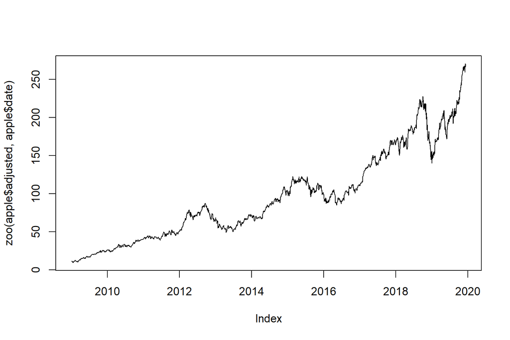

```r
plot(zoo(apple$adjusted, apple$date))
```

<footer></footer>

# Stationarity

### Example: Apple Inc. stock return &mdash; a stationary time series

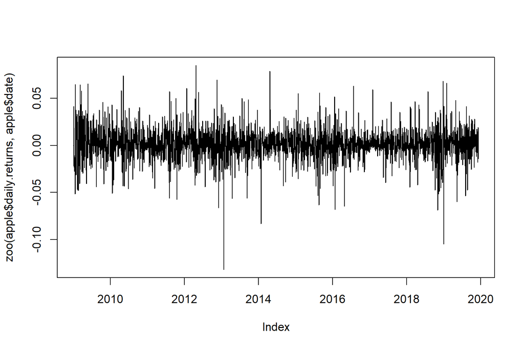

```r
apple <- apple %>% tq_mutate(select = adjusted, mutate_fun = periodReturn,
                             period = "daily", type = "log")
plot(zoo(apple$daily.returns, apple$date))
```

<footer></footer>

# Stationarity

### Mean Reversion

- stationary series exhibit a well-know property referred to as __mean-reversion__: due
to its finite variance, a stationary process can never drift too far from its mean

- the speed of mean reversion is determined by the _autocovariance_: mean reversion
is quick when autocovariances are small and slow when autocovariances are large

- in finance, mean reversion refers to the assumption that security prices tend to
move towards the average price over time: assets seem to be attractive to buy
when the current price is below the average price and vice versa

- in this sense, mean reversion is opposed by the empirically observed tendency for
rising asset prices to rise further and falling prices to keep falling (__momentum__)

<footer></footer>

# Stationarity

### Stationarity vs. Non-Stationarity

- any series with a trend in the mean will not be stationary: when prices appear to
be trending, this is normally due to a stochastic rather than a deterministic trend

- while prices (or log prices) in most markets are non-stationary, the first difference
in prices – or, more usually, the __first difference in log prices__ (as these are approx.
equal to returns) – are modeled as a stationary process

<footer></footer>

# Stationarity

### Integrated Processes

> Let `\(\{y_t\}\)` be a non-stationary process such that `\(\Delta^d\{y_t\}\)` is stationary but
> `\(\Delta^{d-1}\{y_t\}\)` is non-stationary. Then `\(\{y_t\}\)` is called integrated of order `\(d\)`,
denoted `\(y_t \sim I(d)\)`.

__Example:__

- consider the time series process `\(y_t = \mu  + y_{t-1} + u_t\)` where `\(u_t \sim WN(0, \sigma^2)\)`
  (referred to as _random walk with drift_); taking first difference of `\(y_t\)` yields
  `\(\Delta y_t = y_t - y_{t-1} = \mu + u_t\)`, i.e., the white noise error term which
  is stationary

- i.e., a random walk is non-stationary but becomes stationary when taking the
  first difference; thus, a random walk is an _integrated process of order 1_,
  denoted `\(I(1)\)`

<footer></footer>

# Stationarity

### Tests for Stationarity: unit root tests

A number of different statistical tests are available to test whether
a time series is _stationary_ or _non-stationary_:
_(augmented) Dickey-Fuller (GLS) test, Phillips-Perron test, KPPS test_, etc.

- `\(H_0\)`: the (time series) process has a unit root, i.e., is _non-stationary_

- `\(H_1\)`: depending on test, usually _stationarity_ or _trend-stationarity_ of
  the time series

<footer></footer>

# Stationarity

### Tests for Stationarity: unit root tests

```r
library(tseries)
adf.test(apple$adjusted)
```

```
##
## 	Augmented Dickey-Fuller Test
##
## data:  apple$adjusted
## Dickey-Fuller = -1.2799, Lag order = 14, p-value = 0.8832
## alternative hypothesis: stationary
```

```r
pp.test(apple$adjusted)
```

```
##
## 	Phillips-Perron Unit Root Test
##
## data:  apple$adjusted
## Dickey-Fuller Z(alpha) = -4.2365, Truncation lag parameter = 9,
## p-value = 0.8734
## alternative hypothesis: stationary
```

<footer></footer>

# Stationarity

### Tests for Stationarity: unit root tests

```r
adf.test(apple$daily.returns)
```

```
##
## 	Augmented Dickey-Fuller Test
##
## data:  apple$daily.returns
## Dickey-Fuller = -13.693, Lag order = 14, p-value = 0.01
## alternative hypothesis: stationary
```

```r
adf.test(diff(log(apple$adjusted)))
```

```
##
## 	Augmented Dickey-Fuller Test
##
## data:  diff(log(apple$adjusted))
## Dickey-Fuller = -13.669, Lag order = 14, p-value = 0.01
## alternative hypothesis: stationary
```

<footer></footer>

# Stationarity

### Detrending Financial Time Series

- since a trending time series is typically non-stationary, we would like to remove
trends in order to make it a stationary time series (referred to as detrending)

- importantly, trends might either be deterministic or stochastic in nature

- to remove a deterministic trend...
  ... compute deviations from a fitted line

- to remove a stochastic trend...
  ... integrate the process, i.e., take differences

<footer></footer>

# Stationarity

### Detrending Financial Time Series

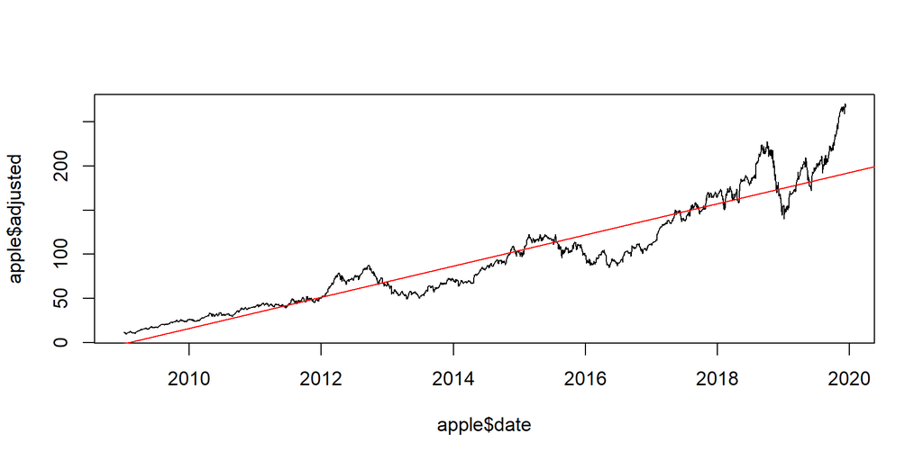

```r
plot(apple$date, apple$adjusted, type="l")
abline(lm(adjusted ~ date, data = apple), col=2)
```

```r
#
#
```

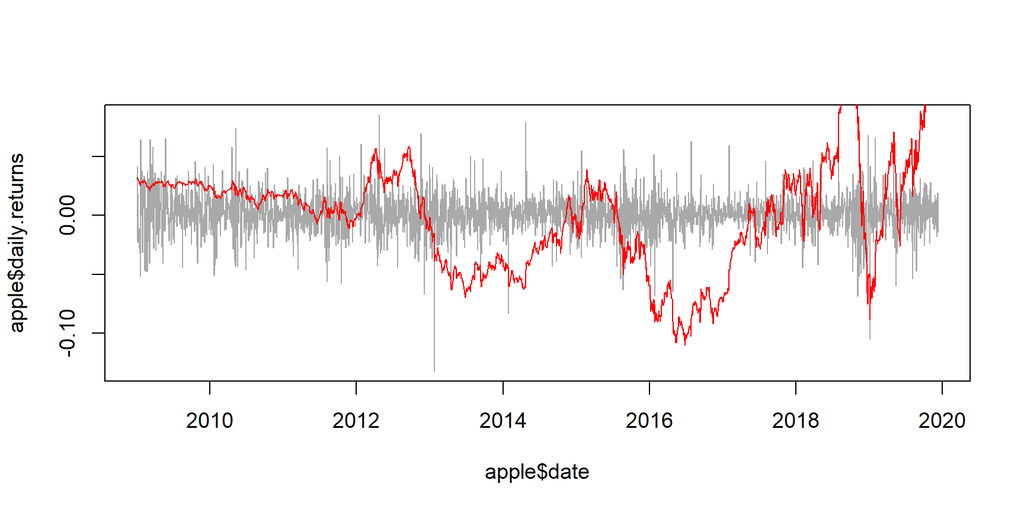

```r
apple$trend <- predict(lm(adjusted ~ date, data = apple))
apple$deviation <- apple$adjusted - apple$trend
plot(apple$date, apple$daily.returns, type = "l", col = "darkgray")
lines(apple$date, apple$deviation/400, col = 2)
```

<footer></footer>

# Autoregressive and Moving Average Models

<footer></footer>

# Autoregressive Processes, AR(p)

- let `\(u_t\)` be a white noise process with `\(E[u_t] = 0\)` and `\(Var[u_t] = \sigma^2\)`, then
an __autoregressive model of order__ `\(p\)`, denoted as `\(AR(p)\)`, is defined as

`\(y_t = \alpha_0 + \alpha_1 y_{t-1} + ... + \alpha_p y_{t-p} + u_t\)`

- i.e., an autoregressive model is a process where the current value of `\(y\)`
  depends only on the value of `\(y\)` in previous periods plus an error term

<footer></footer>

# Autoregressive Processes, AR(p)

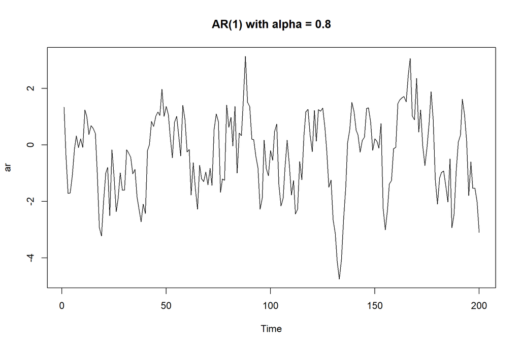

<footer></footer>

# Autoregressive Processes, AR(p)

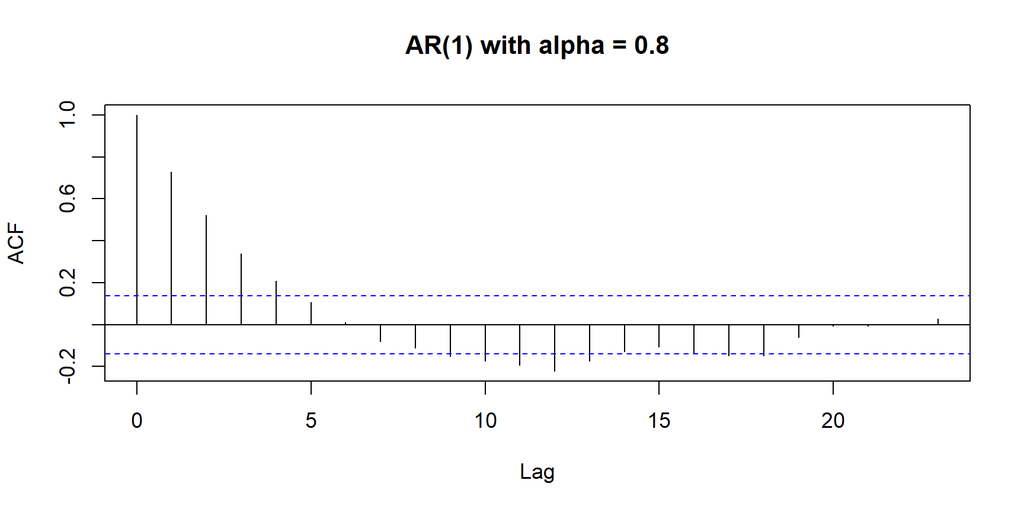

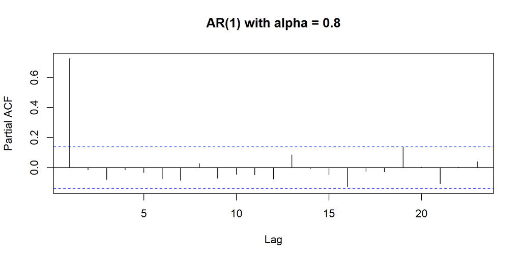

<footer></footer>

# Moving Average Processes, MA(q)

- let `\(u_t\)` be a white noise process with `\(E[u_t] = 0\)` and `\(Var[u_t] = \sigma^2\)`, then a
`\(q^{th}\)` __order moving average processes__, denoted as `\(MA(q)\)`, is defined by

`\(y_t = \mu + u_t + \theta_1 u_{t-1} + \theta_2 u_{t-1} + ... + \theta_q u_{t-q}\)`

- i.e., a moving average model is simply a linear combination of white
noise processes, such that `\(y_t\)` depends on the current and previous values of a
white noise disturbance term

<footer></footer>

# Moving Average Processes, MA(q)

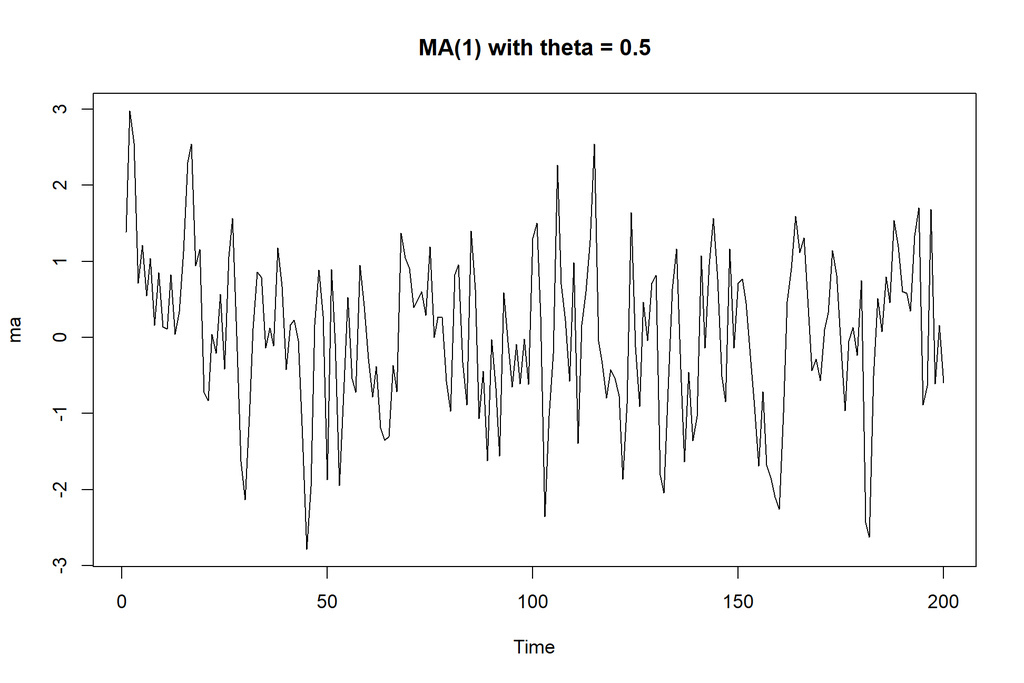

<footer></footer>

# Moving Average Processes, MA(q)

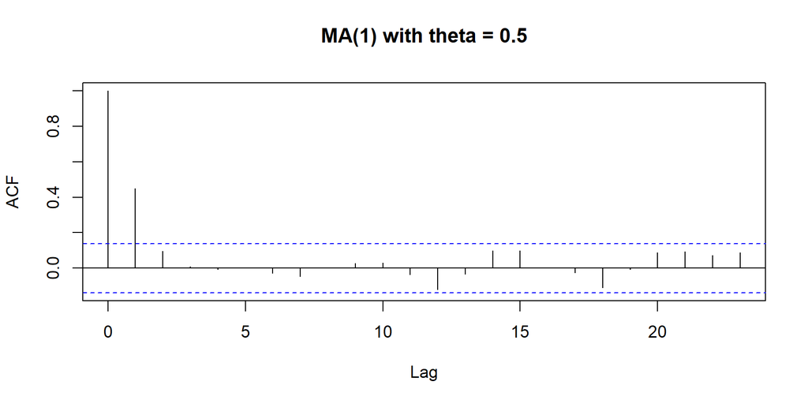

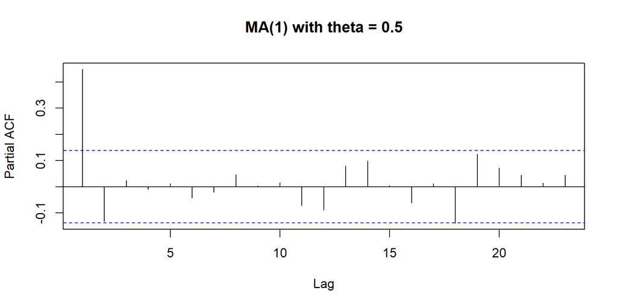

<footer></footer>

# Autoregressive Moving Average Models (ARMA)

- autoregressive moving average models (ARMA) provide a parsimonious description
of a weakly stationary stochastic process in terms of two polynomials, one for the
autoregression and one for the moving average

- i.e., combining an AR(p) and a MA(q) model results in the __ARMA(p,q)__ model

`\(y_t = \alpha_0 + \alpha1 y_{t-1} + ... + \alpha_p y_{t-q} + u_t + \theta_1 u_{t-1} + ... + \theta_q u_{t-q}\)`

__Note:__ if the data shows evidence of non-stationarity, the ARIMA generalization
(autoregressive integrated moving average models) might be applied in order to
eliminate non-stationarity by an initial differencing step

<footer></footer>

# Autoregressive Moving Average Models (ARMA)

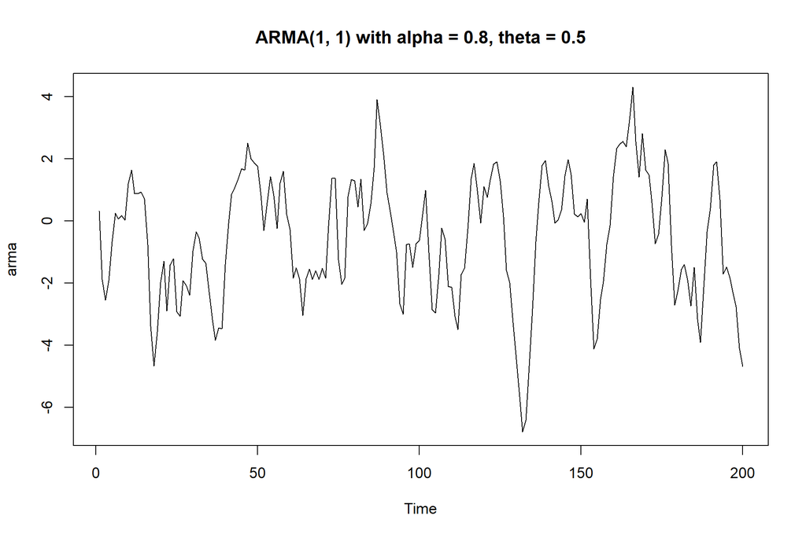

<footer></footer>

# Model Identification

<footer></footer>

# Model Identification

- the most crucial step in time series analysis is to identify and build a model based
on the available data &mdash; i.e., to identify a process which best explains the
observed movements over time

- the aim is to identify a process that leaves the residuals not being different from
a white noise process (i.e., no exploitable information is contained in residuals)

- in order to statistically examine whether a process is significantly different from
white noise, several tests are available (e.g., _portmanteau Q test_, _Bartlett’s test_,
_Box-Pierce test_, or _Ljung-Box test_)

<footer></footer>

# Model Identification

### Box-Jenkins Approach for Modelling Stochastic Processes

__1. stationarity, model specification:__
  check whether the series is stationary, determine the order `\((p, q)\)` of the
  model, apply graphical methods and (partial) autocorrelation function

__2. estimation:__
  estimate the parameters using non-linear least squares or maximum
  likelihood (ordinary least squares will be biased and/or inefficient)

__3. diagnosis, model quality:__
  examine residuals and check the model quality (information criteria)

Aim: establish a model as parsimonious as possible because the variance
of the estimates is inverse proportional to the number of degrees of freedom, i.e.,
parameters in the model to be estimated

<footer></footer>

# Model Identification

### ACF and PACF

| process      	| autocorrelation `\(\rho\)`                                                  	| partial autocorrelation `\(\rho^*\)`                                             	|
|--------------	|-------------------------------------------------------------------------	|------------------------------------------------------------------------------	|
| `\(MA(q)\)`      	| number of `\(ρ\)`'s sig. different from zero determines order of MA process 	| decreasing                                                                   	|
| `\(AR(p)\)`      	| decreasing                                                              	| number of `\(\rho^∗\)`'s sig. different from zero determines order of AR process 	|
| `\(ARMA(p, q)\)` 	| decreasing                                                              	| decreasing                                                                   	|

<footer></footer>

# Model Identification

### Information Criteria

- generally, information criteria can be considered as goodness of fit measures: thus,
information criteria are estimators of the _relative quality_ of statistical models for
a given set of data, providing a means for model selection

- information criteria estimate the relative information lost when a given model is
used to represent the process generating the data (trade-off between simplicity
and goodness-of-fit of the model)

- the smaller the estimator of an information criteria, the smaller the information
loss and, thus, the better the particular model is relative to other models which
are compared

- frequently applied information criteria are:
  - the Akaike information criteria (AIC),
  - the Bayesian information criteria (BIC), and
  - the Hannan-Quinn information criteria (HQIC)

<footer></footer>

# Model Identification

### Example

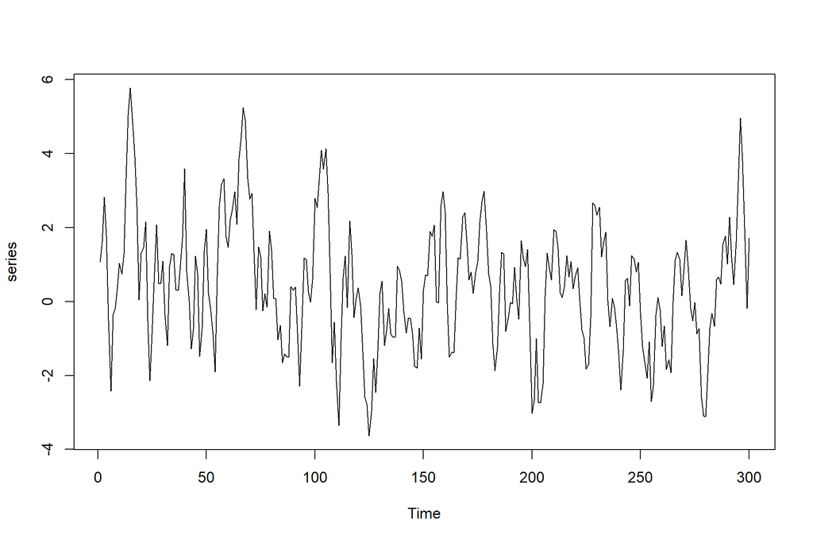

<footer></footer>

# Model Identification

### Example

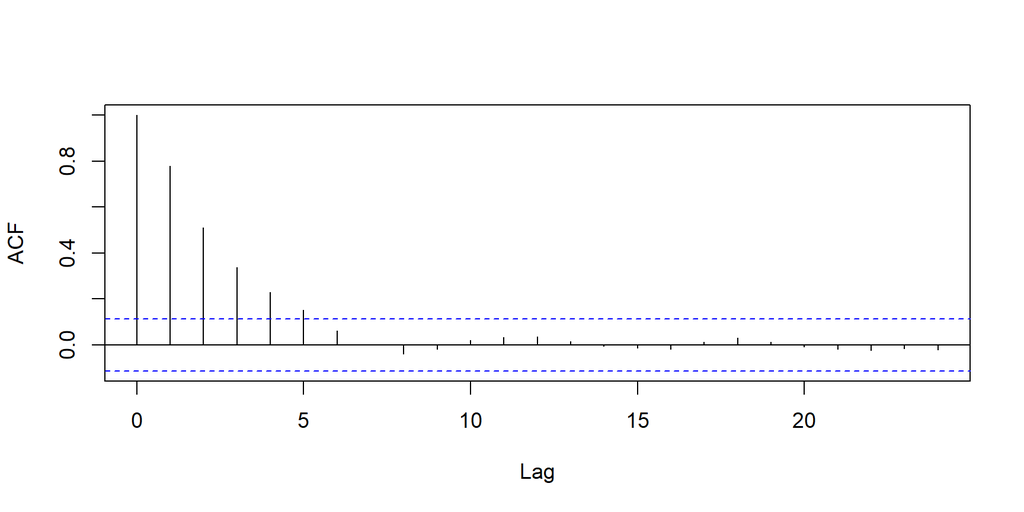

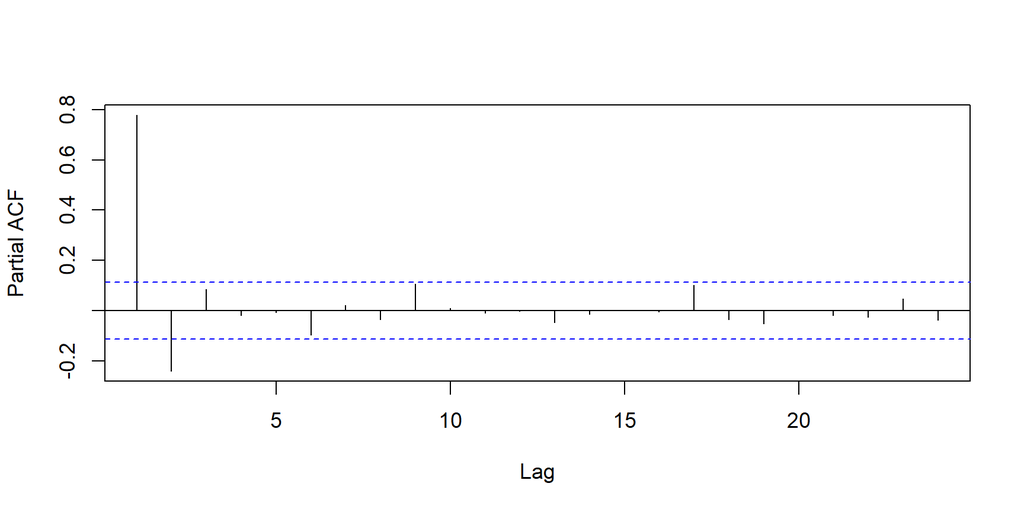

<footer></footer>

# Model Identification

### Example

- __test for stationarity:__
  - augmented Dickey-Fuller test: `\(z(t) = -5.4346, p = 0.01\)`

- __model selection:__
  - choose suitable models based on (partial) autocorrelation function
  - reasonable candidates seem to be `\(AR(1)\)`, `\(MA(1)\)`, and `\(ARMA(1, 1)\)`

<footer></footer>

# Model Identification

### Example

- __model estimation:__

```r
arima(series, order = c(1, 0, 0))
```

```
##
## Call:
## arima(x = series, order = c(1, 0, 0))
##
## Coefficients:
##          ar1  intercept
##       0.7774     0.4637
## s.e.  0.0360     0.2761
##
## sigma^2 estimated as 1.16:  log likelihood = -448.36,  aic = 902.72
```

```r
arima(series, order = c(0, 0, 1))
```

```
##
## Call:
## arima(x = series, order = c(0, 0, 1))
##
## Coefficients:
##          ma1  intercept
##       0.7719     0.4497
## s.e.  0.0322     0.1214
##
## sigma^2 estimated as 1.413:  log likelihood = -478.02,  aic = 962.05
```

```r
arima(series, order = c(1, 0, 1))
```

```
##
## Call:
## arima(x = series, order = c(1, 0, 1))
##
## Coefficients:
##          ar1     ma1  intercept
##       0.6474  0.3556     0.4612
## s.e.  0.0547  0.0703     0.2289
##
## sigma^2 estimated as 1.078:  log likelihood = -437.5,  aic = 883
```

<footer></footer>

# Model Identification

```r
library(forecast)
auto.arima(series, trace = TRUE)
```

```
##
##  Fitting models using approximations to speed things up...
##
##  ARIMA(2,1,2) with drift         : 900.2311
##  ARIMA(0,1,0) with drift         : 932.2426
##  ARIMA(1,1,0) with drift         : 931.5384
##  ARIMA(0,1,1) with drift         : 928.1396
##  ARIMA(0,1,0)                    : 930.2166
##  ARIMA(1,1,2) with drift         : 888.4378
##  ARIMA(0,1,2) with drift         : 913.231
##  ARIMA(1,1,1) with drift         : 925.2665
##  ARIMA(1,1,3) with drift         : 890.4646
##  ARIMA(0,1,3) with drift         : 906.2779
##  ARIMA(2,1,1) with drift         : 903.8821
##  ARIMA(2,1,3) with drift         : 895.117
##  ARIMA(1,1,2)                    : 887.228
##  ARIMA(0,1,2)                    : 911.1791
##  ARIMA(1,1,1)                    : 923.2353
##  ARIMA(2,1,2)                    : 898.3981
##  ARIMA(1,1,3)                    : 889.2575
##  ARIMA(0,1,1)                    : 926.1011
##  ARIMA(0,1,3)                    : 904.2267
##  ARIMA(2,1,1)                    : 901.9089
##  ARIMA(2,1,3)                    : 893.3724
##
##  Now re-fitting the best model(s) without approximations...
##
##  ARIMA(1,1,2)                    : Inf
##  ARIMA(1,1,2) with drift         : Inf
##  ARIMA(1,1,3)                    : Inf
##  ARIMA(1,1,3) with drift         : Inf
##  ARIMA(2,1,3)                    : Inf
##  ARIMA(2,1,3) with drift         : Inf
##  ARIMA(2,1,2)                    : Inf
##  ARIMA(2,1,2) with drift         : Inf
##  ARIMA(2,1,1)                    : 887.2394
##
##  Best model: ARIMA(2,1,1)
```

```
## Series: series
## ARIMA(2,1,1)
##
## Coefficients:
##          ar1      ar2      ma1
##       0.9667  -0.2464  -0.9894
## s.e.  0.0567   0.0565   0.0133
##
## sigma^2 estimated as 1.11:  log likelihood=-439.55
## AIC=887.1   AICc=887.24   BIC=901.91
```